# Unit 3b - Window Functions

Marc Campo

2026-09-19

# APPROACH

I plan to use stock quotes for two, AI related stocks (AMD and NVIDIA) which have moved quite a bit in the past few years and are volatile based on experts vacillating between AI growth explosion, predictions of an AI bubble, and fears of an AI takeover. The true value of the stock probably lies somewhere within but the YTD and moving averages of both should be interesting. Both make chips that are essential for data centers. NVIDIA mostly makes GPUs while AMD makes CPUs but has been heavily invested in the graphics space as well with their integrated and stand-alone Radeon chips after their acquisition of ATI. I own both stocks (in small amounts unfortunately).

# CODE BASE

## Data Overview

Stock data and end of day quotes are available from multiple sources. Initially I used StockQuote.io which offers CSV files for download. I then tried to pull the data directly from Yahoo finance.<sup>1</sup> This will give us one data set we can use window functions with rather than using separate data sets for each stock as I would usually do.

```r
library(jsonlite)
library(dplyr)
library(readr)
library(lubridate)

# Function to pull Yahoo Finance price data
get_yahoo_prices <- function(symbol, range, interval) {

  url <- paste0(
    "https://query1.finance.yahoo.com/v8/finance/chart/",
    symbol,
    "?range=", range,
    "&interval=", interval,
    "&includePrePost=false"
  )

  x <- fromJSON(url, simplifyVector = FALSE)
  result <- x$chart$result[[1]]

  timestamps <- unlist(result$timestamp)
  quote <- result$indicators$quote[[1]]

  # Convert NULL values to NA without dropping rows
  get_num <- function(x) {
    vapply(
      x,
      function(z) {
        if (is.null(z)) NA_real_ else as.numeric(z)
      },
      numeric(1)
    )
  }

  data.frame(
    Symbol = symbol,
    DateTime = as.POSIXct(
      timestamps,
      origin = "1970-01-01",
      tz = "UTC"
    ),
    Open   = get_num(quote$open),
    High   = get_num(quote$high),
    Low    = get_num(quote$low),
    Close  = get_num(quote$close),
    Volume = get_num(quote$volume)
  ) %>%
    mutate(
      DateTime = with_tz(DateTime, "America/New_York")
    )
}

# Hourly data for year to date
daily_YTD <- bind_rows(
  get_yahoo_prices("AMD", "ytd", "1d"),
  get_yahoo_prices("NVDA", "ytd", "1d")
)


# Check data
head(daily_YTD)
```

```
##   Symbol            DateTime   Open   High    Low  Close   Volume
## 1    AMD 2026-01-02 09:30:00 218.90 227.15 218.90 223.47 36446200
## 2    AMD 2026-01-05 09:30:00 230.25 234.02 220.48 221.08 31941100
## 3    AMD 2026-01-06 09:30:00 222.71 222.92 211.25 214.35 40033200
## 4    AMD 2026-01-07 09:30:00 212.13 212.13 207.17 210.02 29715500
## 5    AMD 2026-01-08 09:30:00 210.90 210.94 203.33 204.68 27505000
## 6    AMD 2026-01-09 09:30:00 205.72 207.30 203.07 203.17 24217300
```

## Defining Moving Averages

The assignment calls for using window functions to calculate year-to-date average and the six day moving averages for each item.

There are probably variations that finance experts could point to (I am certainly not one) that may work here. I am interpreting the instructions to mean:

- Calculate, in each row, the year to date average based on that day. This will be the cummulative mean for each day based on all the days in the year up to that point for that stock.
- Calculate, in each row, a 6 day moving average, based on that day. This will be the average of each day plus the 5 previous days for each day of the year for that stock.

*If you look at the prices for these stocks, especially AMD, the YTD average does not tell the full story (except over longer time frames) and reduces the explosive the growth that occurred later in the year. The stock price really took off recently but that is reduced by the lower prices earlier in the year.*

```r
library(dplyr)
daily <- daily_YTD %>%
  mutate(Date = as.Date(DateTime)) %>%
  group_by(Symbol) %>%
  arrange(Date, .by_group = TRUE) %>%
  mutate(
    Daily_Avg_YTD = cummean(Close)
  ) %>%
  ungroup()
head(daily, 10)
```

```
## # A tibble: 10 × 9
##    Symbol DateTime             Open  High   Low Close   Volume Date
##    <chr>  <dttm>              <dbl> <dbl> <dbl> <dbl>    <dbl> <date>
##  1 AMD    2026-01-02 09:30:00  219.  227.  219.  223. 36446200 2026-01-02
##  2 AMD    2026-01-05 09:30:00  230.  234.  220.  221. 31941100 2026-01-05
##  3 AMD    2026-01-06 09:30:00  223.  223.  211.  214. 40033200 2026-01-06
##  4 AMD    2026-01-07 09:30:00  212.  212.  207.  210. 29715500 2026-01-07
##  5 AMD    2026-01-08 09:30:00  211.  211.  203.  205. 27505000 2026-01-08
##  6 AMD    2026-01-09 09:30:00  206.  207.  203.  203. 24217300 2026-01-09
##  7 AMD    2026-01-12 09:30:00  201.  210.  200.  208. 27287300 2026-01-12
##  8 AMD    2026-01-13 09:30:00  215.  223.  215.  221. 56894900 2026-01-13
##  9 AMD    2026-01-14 09:30:00  218.  224.  215.  224. 40466500 2026-01-14
## 10 AMD    2026-01-15 09:30:00  228.  238.  227.  228. 55270200 2026-01-15
## # ℹ 1 more variable: Daily_Avg_YTD <dbl>
```

## Plot YTD Averages

I am plotting the YTD averages for both stocks. I am using DPLYR to avoid creating new data sets to use in ggplot. This reduces the clutter in my environment. I normally would have created new data sets by writing daily_amd_ytd <- daily[daily$Symbol==“AMD”,] and my environment usually ends up with dozens of objects with many only used once.

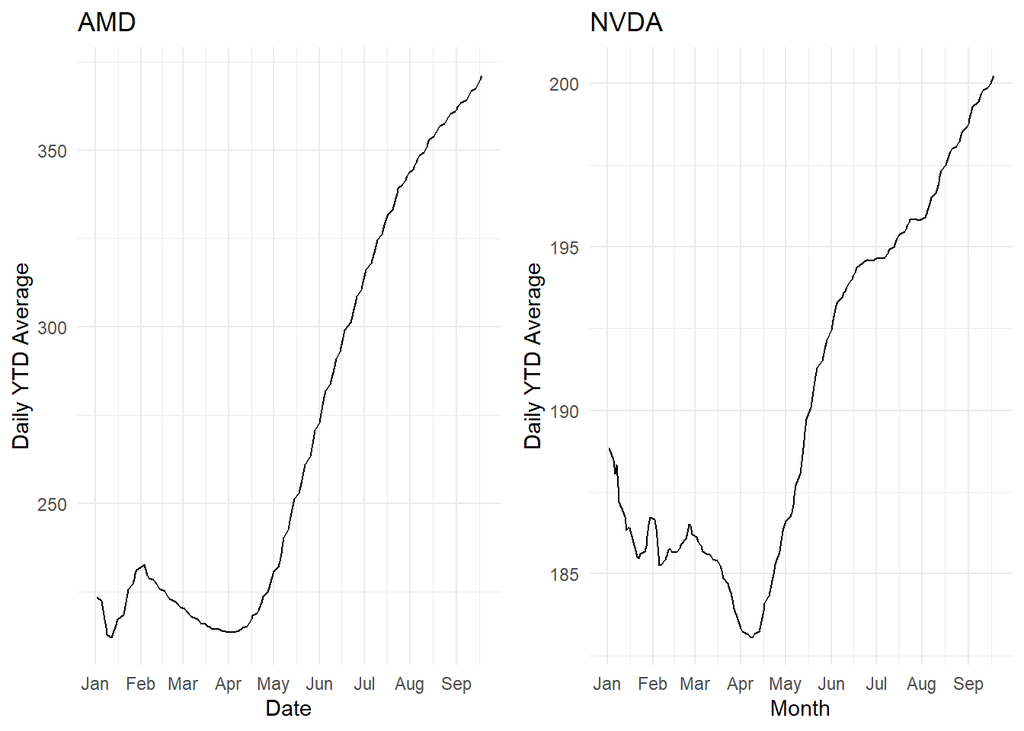

```r
library(ggplot2)
library(gridExtra)

p1 <- daily %>%
  filter(Symbol=="AMD") %>%
ggplot(aes(x=Date, y=Daily_Avg_YTD)) + geom_line() + scale_x_date(date_breaks = "1 month", date_labels = '%b') + ylab("Daily YTD Average") + theme_minimal() + ggtitle("AMD")
p2 <- daily %>%
  filter(Symbol=="NVDA") %>%
ggplot(aes(x=Date, y=Daily_Avg_YTD)) + geom_line() + scale_x_date(date_breaks = "1 month", date_labels = '%b') + ylab("Daily YTD Average") + xlab("Month") + theme_minimal() + ggtitle("NVDA")

grid.arrange(p1,p2, ncol=2)
```

## 6 Day Moving Averages

I created a new data frame with 6 day moving averages. k=6 results in a moving 6-day average for the end of day quotes. These should show the dramatic growth more clearly.

```r
daily_6d <- daily_YTD %>%
  group_by(Symbol) %>%
  arrange(DateTime, .by_group = TRUE) %>%
  mutate(
    SixDay = zoo::rollmean(
      Close,
      k = 6,
      fill = NA,
      align = "right"
    )
  ) %>%
  ungroup()
head(daily_6d,10)
```

```
## # A tibble: 10 × 8
##    Symbol DateTime             Open  High   Low Close   Volume SixDay
##    <chr>  <dttm>              <dbl> <dbl> <dbl> <dbl>    <dbl>  <dbl>
##  1 AMD    2026-01-02 09:30:00  219.  227.  219.  223. 36446200    NA
##  2 AMD    2026-01-05 09:30:00  230.  234.  220.  221. 31941100    NA
##  3 AMD    2026-01-06 09:30:00  223.  223.  211.  214. 40033200    NA
##  4 AMD    2026-01-07 09:30:00  212.  212.  207.  210. 29715500    NA
##  5 AMD    2026-01-08 09:30:00  211.  211.  203.  205. 27505000    NA
##  6 AMD    2026-01-09 09:30:00  206.  207.  203.  203. 24217300   213.
##  7 AMD    2026-01-12 09:30:00  201.  210.  200.  208. 27287300   210.
##  8 AMD    2026-01-13 09:30:00  215.  223.  215.  221. 56894900   210.
##  9 AMD    2026-01-14 09:30:00  218.  224.  215.  224. 40466500   212.
## 10 AMD    2026-01-15 09:30:00  228.  238.  227.  228. 55270200   215.
```

## Create Plots

In the plots below you can see the true scale of the growth for both stocks, particularly for AMD. NVidia stock used to be much higher but was split within the past few years.

[figure not shown]

```r
p3 <- daily_6d %>%
  filter(Symbol=="AMD") %>%
ggplot(aes(x=DateTime, y=SixDay)) + geom_line() + scale_x_date(date_breaks = "1 month", date_labels = '%b') + ylab("Daily 6-Day Moving Average") + theme_minimal() + ggtitle("AMD") + xlab("Month")
p4 <- daily_6d %>%
  filter(Symbol=="NVDA") %>%
ggplot(aes(x=DateTime, y=SixDay)) + geom_line() + scale_x_date(date_breaks = "1 month", date_labels = '%b') + ylab("Daily 6-Day Moving Average") + xlab("Month") + theme_minimal() + ggtitle("NVDA")

grid.arrange(p3,p4, ncol=2)
```

## Acknowledgements

ChatGPT<sup>2</sup> was used to develop and refine code for pulling finance data from Yahoo Finance.

## References

1. Yahoo Finance. Yahoo Finance. Accessed September 19, 2026. https://finance.yahoo.com/
2. OpenAI. ChatGPT (GPT-5.6 Sol) [large language model]. Accessed September 19, 2026.